# WDI Template

#### 2.1.2.3 Ranking of CO<sub>2</sub> per capita

```r
df_co2gdp |> filter(year == 2020) |> filter(region != "Aggregates") |>
  drop_na(co2pcap) |> arrange(desc(co2pcap))
```

| country | iso2c | iso3c | year | status | lastupdated | co2pcap | gdppcap | region | capital | longitude | latitude | income | lending |
| --- | --- | --- | --- | --- | --- | --- | --- | --- | --- | --- | --- | --- | --- |
| Qatar | QA | QAT | 2020 | NA | 2023-09-19 | 31.72684245 | 89019.0699 | Middle East & North Africa | Doha | 51.508200 | 25.294800 | High income | Not classified |
| Bahrain | BH | BHR | 2020 | NA | 2023-09-19 | 21.97690781 | 47994.4143 | Middle East & North Africa | Manama | 50.535400 | 26.192100 | High income | Not classified |
| Brunei Darussalam | BN | BRN | 2020 | NA | 2023-09-19 | 21.70581244 | 61603.5508 | East Asia & Pacific | Bandar Seri Begawan | 114.946000 | 4.941990 | High income | Not classified |
| Kuwait | KW | KWT | 2020 | NA | 2023-09-19 | 21.16961025 | 43922.6302 | Middle East & North Africa | Kuwait City | 47.982400 | 29.372100 | High income | Not classified |
| United Arab Emirates | AE | ARE | 2020 | NA | 2023-09-19 | 20.25227168 | 67668.2866 | Middle East & North Africa | Abu Dhabi | 54.370500 | 24.476400 | High income | Not classified |
| Oman | OM | OMN | 2020 | NA | 2023-09-19 | 15.63620100 | 33098.2099 | Middle East & North Africa | Muscat | 58.587400 | 23.610500 | High income | Not classified |
| Australia | AU | AUS | 2020 | NA | 2023-09-19 | 14.77265760 | 48747.8517 | East Asia & Pacific | Canberra | 149.129000 | -35.282000 | High income | Not classified |
| Saudi Arabia | SA | SAU | 2020 | NA | 2023-09-19 | 14.26658537 | 44770.9083 | Middle East & North Africa | Riyadh | 46.697700 | 24.674800 | High income | Not classified |
| Canada | CA | CAN | 2020 | NA | 2023-09-19 | 13.59937492 | 46181.7576 | North America | Ottawa | -75.691900 | 45.421500 | High income | Not classified |
| United States | US | USA | 2020 | NA | 2023-09-19 | 13.03282795 | 60158.9105 | North America | Washington D.C. | -77.032000 | 38.889500 | High income | Not classified |

[output cut: 180 more lines]

```r
df_co2gdp |> filter(year == 2020) |> filter(region != "Aggregates") |>
  drop_na(co2pcap) |> arrange(co2pcap)
```

| country | iso2c | iso3c | year | status | lastupdated | co2pcap | gdppcap | region | capital | longitude | latitude | income | lending |
| --- | --- | --- | --- | --- | --- | --- | --- | --- | --- | --- | --- | --- | --- |
| Congo, Dem. Rep. | CD | COD | 2020 | NA | 2023-09-19 | 0.03258478 | 1044.0712 | Sub-Saharan Africa | Kinshasa | 15.322200 | -4.325000 | Low income | IDA |
| Somalia | SO | SOM | 2020 | NA | 2023-09-19 | 0.03993465 | 1127.4185 | Sub-Saharan Africa | Mogadishu | 45.325400 | 2.075150 | Low income | IDA |
| Central African Republic | CF | CAF | 2020 | NA | 2023-09-19 | 0.04428207 | 847.7650 | Sub-Saharan Africa | Bangui | 21.640700 | 5.630560 | Low income | IDA |
| Burundi | BI | BDI | 2020 | NA | 2023-09-19 | 0.05838402 | 711.3553 | Sub-Saharan Africa | Bujumbura | 29.363900 | -3.378400 | Low income | IDA |
| Malawi | MW | MWI | 2020 | NA | 2023-09-19 | 0.08463616 | 1489.6014 | Sub-Saharan Africa | Lilongwe | 33.770300 | -13.989900 | Low income | IDA |
| Niger | NE | NER | 2020 | NA | 2023-09-19 | 0.09032558 | 1214.5466 | Sub-Saharan Africa | Niamey | 2.107300 | 13.514000 | Low income | IDA |
| Chad | TD | TCD | 2020 | NA | 2023-09-19 | 0.09422819 | 1489.1867 | Sub-Saharan Africa | N'Djamena | 15.044500 | 12.104800 | Low income | IDA |
| Madagascar | MG | MDG | 2020 | NA | 2023-09-19 | 0.09726954 | 1436.2070 | Sub-Saharan Africa | Antananarivo | 45.716700 | -20.466700 | Low income | IDA |
| Rwanda | RW | RWA | 2020 | NA | 2023-09-19 | 0.10512414 | 2066.6287 | Sub-Saharan Africa | Kigali | 30.058700 | -1.953250 | Low income | IDA |
| Sierra Leone | SL | SLE | 2020 | NA | 2023-09-19 | 0.12727761 | 1586.3549 | Sub-Saharan Africa | Freetown | -13.213400 | 8.482100 | Low income | IDA |

[output cut: 180 more lines]

**Observations and Questions:**

- Top 10 countries of CO<sub>2</sub> emission per capita:
  - Qtar, Bahrain, Brunei Darussalam, Kuwait, United Arab Emirates, Oman, Australia, Saudi Arabia, Canada, and United States
- Lowest 10 countries of CO<sub>2</sub> emission per capita:
  - Congo, Dem. Rep., Somalia, Central African Republic, Burundi, Malawi, Niger, Chad, Madagascar, Rwanda, Sierra Leone

#### 2.1.2.4 Ranking of GDP per capita

```r
df_co2gdp |> filter(year == 2020) |> filter(region != "Aggregates") |>
  drop_na(gdppcap) |> arrange(desc(gdppcap))
```

| country | iso2c | iso3c | year | status | lastupdated | co2pcap | gdppcap | region | capital | longitude | latitude | income | lending |
| --- | --- | --- | --- | --- | --- | --- | --- | --- | --- | --- | --- | --- | --- |
| Luxembourg | LU | LUX | 2020 | NA | 2023-09-19 | 12.45695323 | 111751.3148 | Europe & Central Asia | Luxembourg | 6.129600 | 49.610000 | High income | Not classified |
| Singapore | SG | SGP | 2020 | NA | 2023-09-19 | 7.68668370 | 94910.1014 | East Asia & Pacific | Singapore | 103.850000 | 1.289410 | High income | Not classified |
| Ireland | IE | IRL | 2020 | NA | 2023-09-19 | 6.76822759 | 91356.8551 | Europe & Central Asia | Dublin | -6.267490 | 53.344100 | High income | Not classified |
| Qatar | QA | QAT | 2020 | NA | 2023-09-19 | 31.72684245 | 89019.0699 | Middle East & North Africa | Doha | 51.508200 | 25.294800 | High income | Not classified |
| Bermuda | BM | BMU | 2020 | NA | 2023-09-19 | NA | 76117.8047 | North America | Hamilton | -64.706000 | 32.329300 | High income | Not classified |
| Switzerland | CH | CHE | 2020 | NA | 2023-09-19 | 4.04207281 | 67765.8814 | Europe & Central Asia | Bern | 7.448210 | 46.948000 | High income | Not classified |
| United Arab Emirates | AE | ARE | 2020 | NA | 2023-09-19 | 20.25227168 | 67668.2866 | Middle East & North Africa | Abu Dhabi | 54.370500 | 24.476400 | High income | Not classified |
| Cayman Islands | KY | CYM | 2020 | NA | 2023-09-19 | NA | 67530.6938 | Latin America & Caribbean | George Town | -81.385700 | 19.302200 | High income | Not classified |
| Norway | NO | NOR | 2020 | NA | 2023-09-19 | 6.72508005 | 63776.1610 | Europe & Central Asia | Oslo | 10.738700 | 59.913800 | High income | Not classified |
| Brunei Darussalam | BN | BRN | 2020 | NA | 2023-09-19 | 21.70581244 | 61603.5508 | East Asia & Pacific | Bandar Seri Begawan | 114.946000 | 4.941990 | High income | Not classified |

[output cut: 183 more lines]

```r
df_co2gdp |> filter(year == 2020) |> filter(region != "Aggregates") |>
  drop_na(gdppcap) |> arrange(gdppcap)
```

| country | iso2c | iso3c | year | status | lastupdated | co2pcap | gdppcap | region | capital | longitude | latitude | income | lending |
| --- | --- | --- | --- | --- | --- | --- | --- | --- | --- | --- | --- | --- | --- |
| Burundi | BI | BDI | 2020 | NA | 2023-09-19 | 0.05838402 | 711.3553 | Sub-Saharan Africa | Bujumbura | 29.363900 | -3.378400 | Low income | IDA |
| Central African Republic | CF | CAF | 2020 | NA | 2023-09-19 | 0.04428207 | 847.7650 | Sub-Saharan Africa | Bangui | 21.640700 | 5.630560 | Low income | IDA |
| Congo, Dem. Rep. | CD | COD | 2020 | NA | 2023-09-19 | 0.03258478 | 1044.0712 | Sub-Saharan Africa | Kinshasa | 15.322200 | -4.325000 | Low income | IDA |
| Somalia | SO | SOM | 2020 | NA | 2023-09-19 | 0.03993465 | 1127.4185 | Sub-Saharan Africa | Mogadishu | 45.325400 | 2.075150 | Low income | IDA |
| Niger | NE | NER | 2020 | NA | 2023-09-19 | 0.09032558 | 1214.5466 | Sub-Saharan Africa | Niamey | 2.107300 | 13.514000 | Low income | IDA |
| Mozambique | MZ | MOZ | 2020 | NA | 2023-09-19 | 0.22276755 | 1233.4250 | Sub-Saharan Africa | Maputo | 32.571300 | -25.966400 | Low income | IDA |
| Liberia | LR | LBR | 2020 | NA | 2023-09-19 | 0.23183892 | 1383.8281 | Sub-Saharan Africa | Monrovia | -10.795700 | 6.300390 | Low income | IDA |
| Madagascar | MG | MDG | 2020 | NA | 2023-09-19 | 0.09726954 | 1436.2070 | Sub-Saharan Africa | Antananarivo | 45.716700 | -20.466700 | Low income | IDA |
| Chad | TD | TCD | 2020 | NA | 2023-09-19 | 0.09422819 | 1489.1867 | Sub-Saharan Africa | N'Djamena | 15.044500 | 12.104800 | Low income | IDA |
| Malawi | MW | MWI | 2020 | NA | 2023-09-19 | 0.08463616 | 1489.6014 | Sub-Saharan Africa | Lilongwe | 33.770300 | -13.989900 | Low income | IDA |

[output cut: 183 more lines]

### 2.1.3 Histograms and Boxplots for Variation

#### 2.1.3.1 CO<sub>2</sub> per capita

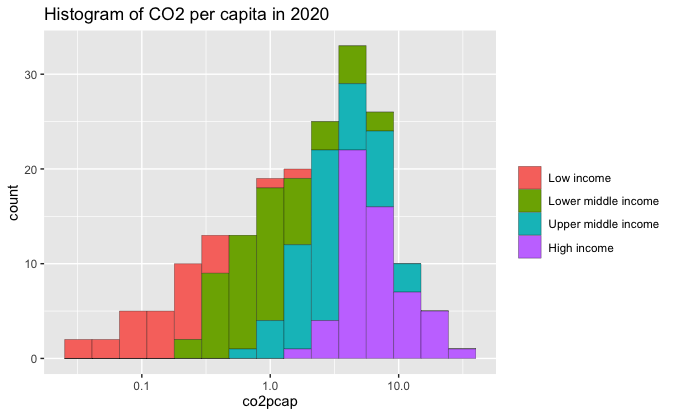

```r
INCOME <- c("Low income", "Low & middle income", "Lower middle income", "Middle income", "Upper middle income", "High income")
df_co2gdp |> filter(year == 2020) |> filter(region != "Aggregates") |>
  drop_na(co2pcap) |> filter(income != "Not classified") |>
  ggplot(aes(co2pcap, fill = factor(income, levels = INCOME))) + geom_histogram(bins = 15, col = "black", linewidth = 0.1) +
  scale_x_log10() +
  labs(title = "Histogram of CO2 per capita in 2020", fill = "")
```

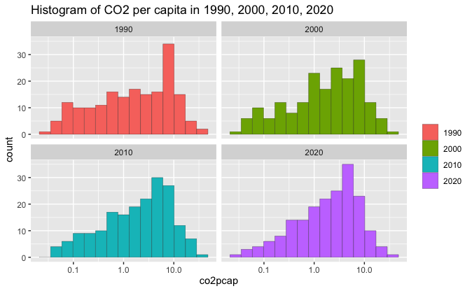

```r
df_co2gdp |> filter(year %in% c(1990, 2000, 2010, 2020)) |> filter(region != "Aggregates") |>
  drop_na(co2pcap) |> filter(co2pcap > 0) |> filter(income != "Not classified") |>
  ggplot(aes(co2pcap, fill = factor(year))) +
  geom_histogram(bins = 15, col = "black", linewidth = 0.1) +
  scale_x_log10() + facet_wrap(~year) +
  labs(title = "Histogram of CO2 per capita in 1990, 2000, 2010, 2020", fill = "")
```

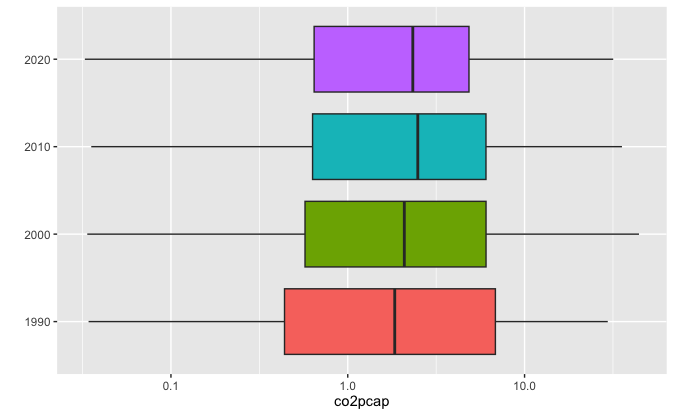

```r
df_co2gdp |> filter(year %in% c(1990, 2000, 2010, 2020)) |> filter(region != "Aggregates") |>
  drop_na(co2pcap) |> filter(co2pcap > 0) |> filter(income != "Not classified") |>
  ggplot(aes(co2pcap, factor(year), fill = factor(year))) +
  geom_boxplot() + scale_x_log10() + labs(y = "") + theme(legend.position = "none")
```

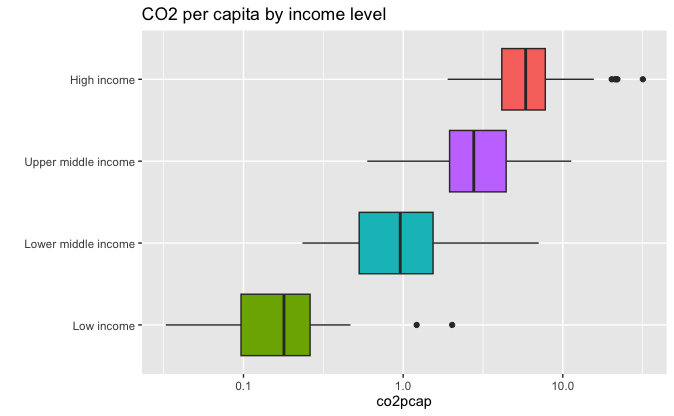

```r
df_co2gdp |> filter(year == 2020) |> filter(region != "Aggregates") |>
  drop_na(co2pcap) |> filter(co2pcap > 0) |> filter(income != "Not classified") |>
  ggplot(aes(co2pcap, factor(income, levels = INCOME), fill = income)) +
  geom_boxplot() + scale_x_log10() +
  labs(title = "CO2 per capita by income level", y = "", fill = "") +
  theme(legend.position = "none")
```

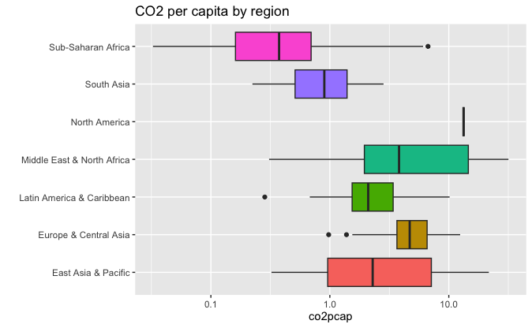

```r
df_co2gdp |> filter(year == 2020) |> filter(region != "Aggregates") |>
  drop_na(co2pcap) |> filter(co2pcap > 0) |>
  ggplot(aes(co2pcap, region, fill = region)) +
  geom_boxplot() + scale_x_log10() +
  labs(title = "CO2 per capita by region", y = "", fill = "") +
  theme(legend.position = "none")
```

#### 2.1.3.2 GDP per capita

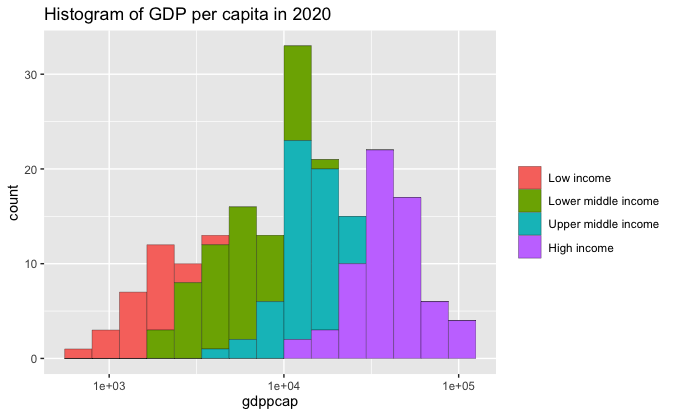

```r
df_co2gdp |> filter(year == 2020) |> filter(region != "Aggregates") |>
  drop_na(gdppcap) |> filter(income != "Not classified") |>
  ggplot(aes(gdppcap, fill = factor(income, levels = INCOME))) + geom_histogram(bins = 15, col = "black", linewidth = 0.1) +
  scale_x_log10() +
  labs(title = "Histogram of GDP per capita in 2020", fill = "")
```

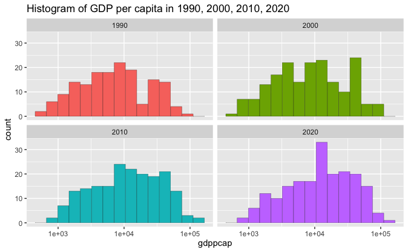

```r
df_co2gdp |> filter(year %in% c(1990, 2000, 2010, 2020)) |> filter(region != "Aggregates") |>
  drop_na(gdppcap) |> filter(gdppcap > 0) |> filter(income != "Not classified") |>
  ggplot(aes(gdppcap, fill = factor(year))) +
  geom_histogram(bins = 15, col = "black", linewidth = 0.1) +
  scale_x_log10() + facet_wrap(~year) +
  labs(title = "Histogram of GDP per capita in 1990, 2000, 2010, 2020", fill = "") +
  theme(legend.position = "none")
```

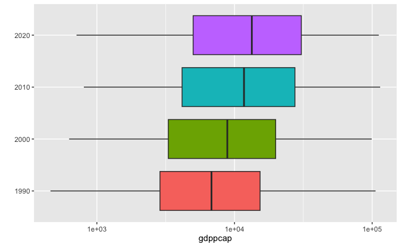

```r
df_co2gdp |> filter(year %in% c(1990, 2000, 2010, 2020)) |> filter(region != "Aggregates") |>
  drop_na(gdppcap) |> filter(gdppcap > 0) |> filter(income != "Not classified") |>
  ggplot(aes(gdppcap, factor(year), fill = factor(year))) +
  geom_boxplot() + scale_x_log10() + labs(y = "") + theme(legend.position = "none")
```

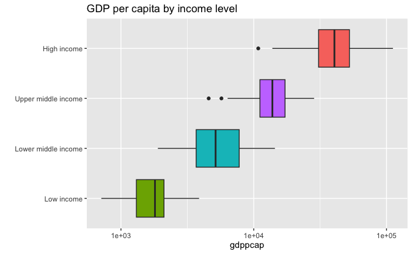

```r
df_co2gdp |> filter(year == 2020) |> filter(region != "Aggregates") |>
  drop_na(gdppcap) |> filter(gdppcap > 0) |> filter(income != "Not classified") |>
  ggplot(aes(gdppcap, factor(income, levels = INCOME), fill = income)) +
  geom_boxplot() + scale_x_log10() +
  labs(title = "GDP per capita by income level", y = "", fill = "") +
  theme(legend.position = "none")
```

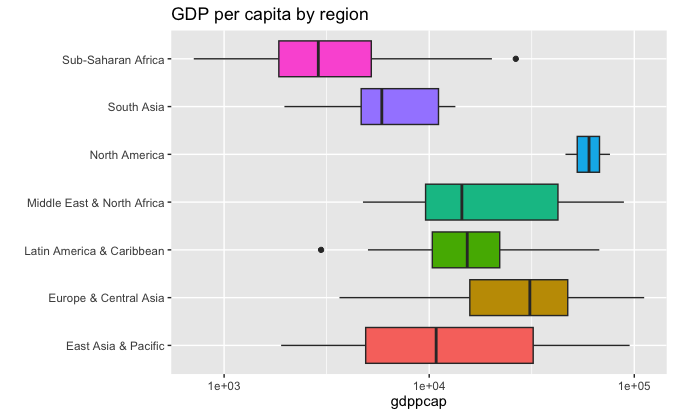

```r
df_co2gdp |> filter(year == 2020) |> filter(region != "Aggregates") |>
  drop_na(gdppcap) |> filter(gdppcap > 0) |>
  ggplot(aes(gdppcap, region, fill = region)) +
  geom_boxplot() + scale_x_log10() +
  labs(title = "GDP per capita by region", y = "", fill = "") +
  theme(legend.position = "none")
```

### 2.1.4 Scatterplot for Covariation

#### 2.1.4.1 Scatterplot with a regression line

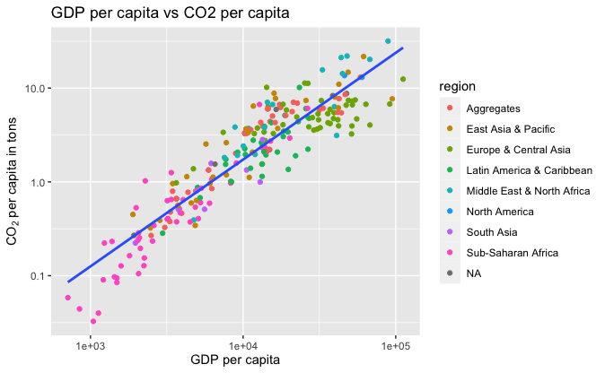

```r
df_co2gdp |> filter(year == 2020) |>
  drop_na(gdppcap, co2pcap) |>
  ggplot(aes(gdppcap, co2pcap)) + geom_point(aes(col = region)) +
  geom_smooth(method = "lm", formula = 'y~x', se = FALSE) +
  scale_x_log10() + scale_y_log10() +
  labs(title = "GDP per capita vs CO2 per capita",
       x = "GDP per capita",
       y = expression(paste(CO[2], " per capita in tons")))
```

#### 2.1.4.2 Summary of a linear model

```r
df_co2gdp |> filter(year == 2020) |> drop_na(gdppcap, co2pcap) |>
  lm(log10(co2pcap)~log10(gdppcap), data = _) |> summary()
```

```
Call:
lm(formula = log10(co2pcap) ~ log10(gdppcap), data = drop_na(filter(df_co2gdp,
    year == 2020), gdppcap, co2pcap))

Residuals:
     Min       1Q   Median       3Q      Max
-0.60778 -0.15660 -0.00651  0.16129  0.59437

Coefficients:
               Estimate Std. Error t value Pr(>|t|)
(Intercept)    -4.31545    0.13386  -32.24   <2e-16 ***
log10(gdppcap)  1.13831    0.03288   34.62   <2e-16 ***
---
Signif. codes:  0 ‘***’ 0.001 ‘**’ 0.01 ‘*’ 0.05 ‘.’ 0.1 ‘ ’ 1

Residual standard error: 0.2362 on 228 degrees of freedom
Multiple R-squared:  0.8402,    Adjusted R-squared:  0.8395
F-statistic:  1199 on 1 and 228 DF,  p-value: < 2.2e-16
```

## 2.2 School Enrollment vs GDP Per Capita

### 2.2.1 Index Search

```r
WDIsearch(string = "school enrollment.*(% gross)", field = "name", short = FALSE)
```

|  | indicator | name | description | sourceDatabase | sourceOrganization |
| --- | --- | --- | --- | --- | --- |
| 15203 | SE.PRE.ENRR | School enrollment, preprimary (% gross) | Gross enrollment ratio is the ratio of total enrollment, regardless of age, to the population of the age group that officially corresponds to the level of education shown. Preprimary education refers … | World Development Indicators | UNESCO Institute for Statistics (http://uis.unesco.org/). Data as of June 2022. |
| 15204 | SE.PRE.ENRR.FE | School enrollment, preprimary, female (% gross) | Gross enrollment ratio is the ratio of total enrollment, regardless of age, to the population of the age group that officially corresponds to the level of education shown. Preprimary education refers … | World Development Indicators | UNESCO Institute for Statistics (http://uis.unesco.org/). Data as of June 2022. |
| 15205 | SE.PRE.ENRR.MA | School enrollment, preprimary, male (% gross) | Gross enrollment ratio is the ratio of total enrollment, regardless of age, to the population of the age group that officially corresponds to the level of education shown. Preprimary education refers … | World Development Indicators | UNESCO Institute for Statistics (http://uis.unesco.org/). Data as of June 2022. |
| 15298 | SE.PRM.ENRR | School enrollment, primary (% gross) | Gross enrollment ratio is the ratio of total enrollment, regardless of age, to the population of the age group that officially corresponds to the level of education shown. Primary education provides c… | World Development Indicators | UNESCO Institute for Statistics (http://uis.unesco.org/). Data as of June 2022. |
| 15299 | SE.PRM.ENRR.FE | School enrollment, primary, female (% gross) | Gross enrollment ratio is the ratio of total enrollment, regardless of age, to the population of the age group that officially corresponds to the level of education shown. Primary education provides c… | World Development Indicators | UNESCO Institute for Statistics (http://uis.unesco.org/). Data as of June 2022. |
| 15300 | SE.PRM.ENRR.MA | School enrollment, primary, male (% gross) | Gross enrollment ratio is the ratio of total enrollment, regardless of age, to the population of the age group that officially corresponds to the level of education shown. Primary education provides c… | World Development Indicators | UNESCO Institute for Statistics (http://uis.unesco.org/). Data as of June 2022. |
| 15786 | SE.SEC.ENRR | School enrollment, secondary (% gross) | Gross enrollment ratio is the ratio of total enrollment, regardless of age, to the population of the age group that officially corresponds to the level of education shown. Secondary education complete… | World Development Indicators | UNESCO Institute for Statistics (http://uis.unesco.org/). Data as of June 2022. |
| 15787 | SE.SEC.ENRR.FE | School enrollment, secondary, female (% gross) | Gross enrollment ratio is the ratio of total enrollment, regardless of age, to the population of the age group that officially corresponds to the level of education shown. Secondary education complete… | World Development Indicators | UNESCO Institute for Statistics (http://uis.unesco.org/). Data as of June 2022. |
| 15791 | SE.SEC.ENRR.MA | School enrollment, secondary, male (% gross) | Gross enrollment ratio is the ratio of total enrollment, regardless of age, to the population of the age group that officially corresponds to the level of education shown. Secondary education complete… | World Development Indicators | UNESCO Institute for Statistics (http://uis.unesco.org/). Data as of June 2022. |
| 15857 | SE.TER.ENRR | School enrollment, tertiary (% gross) | Gross enrollment ratio is the ratio of total enrollment, regardless of age, to the population of the age group that officially corresponds to the level of education shown. Tertiary education, whether … | World Development Indicators | UNESCO Institute for Statistics (http://uis.unesco.org/). Data as of June 2022. |

[output cut: 2 more lines]

1. School enrollment, secondary (% gross): SE.SEC.ENRR
- School enrollment, secondary (% gross) Gross enrollment ratio is the ratio of total enrollment, regardless of age, to the population of the age group that officially corresponds to the level of education shown. Secondary education completes the provision of basic education that began at the primary level, and aims at laying the foundations for lifelong learning and human development, by offering more subject- or skill-oriented instruction using more specialized teachers.
2. School enrollment, tertiary (% gross): SE.TER.ENRR
- Gross enrollment ratio is the ratio of total enrollment, regardless of age, to the population of the age group that officially corresponds to the level of education shown. Tertiary education, whether or not to an advanced research qualification, normally requires, as a minimum condition of admission, the successful completion of education at the secondary level.
3. GDP per capita, PPP (constant 2017 international $): NY.GDP.PCAP.PP.KD
- GDP per capita, PPP (constant 2017 international $) GDP per capita based on purchasing power parity (PPP). PPP GDP is gross domestic product converted to international dollars using purchasing power parity rates. An international dollar has the same purchasing power over GDP as the U.S. dollar has in the United States. GDP at purchaser’s prices is the sum of gross value added by all resident producers in the country plus any product taxes and minus any subsidies not included in the value of the products. It is calculated without making deductions for depreciation of fabricated assets or for depletion and degradation of natural resources. Data are in constant 2017 international dollars.

### 2.2.2 Importing Data

```r
df_sec_ter_gdp <- WDI(indicator = c(sec = "SE.SEC.ENRR", ter = "SE.TER.ENRR",
                                    gdppcap = "NY.GDP.PCAP.PP.KD"), extra = TRUE)
```

```r
write_csv(df_secgdp, "data/sec_ter_gdp.csv")
```

```r
df_secgdp <- read_csv("data/sec_ter_gdp.csv")
```

### 2.2.3 Visualization by Line Graphs

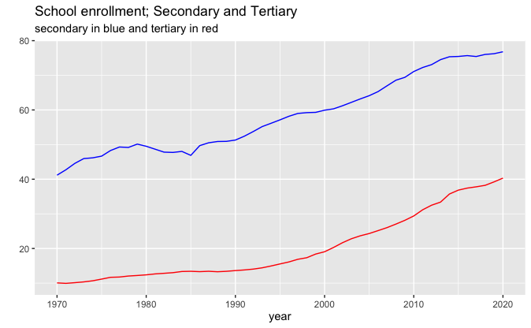

```r
COUNTRY <- "World"
df_sec_ter_gdp |> filter(country == COUNTRY) |> drop_na(sec, ter) |>
  ggplot() + geom_line(aes(year, sec), col = "blue") + geom_line(aes(year, ter), col = "red") +
  labs(title = "School enrollment; Secondary and Tertiary",
       subtitle = "secondary in blue and tertiary in red", y = "")
```

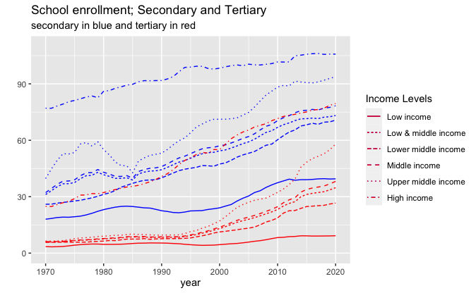

```r
INCOME <- c("Low income", "Low & middle income", "Lower middle income", "Middle income", "Upper middle income", "High income")
df_sec_ter_gdp |> filter(country %in% INCOME) |> drop_na(sec, ter) |>
  ggplot(aes(linetype = factor(country, levels = INCOME))) + geom_line(aes(year, sec), col = "blue") + geom_line(aes(year, ter), col = "red") + ylim(c(0,110)) +
  labs(title = "School enrollment; Secondary and Tertiary",
       subtitle = "secondary in blue and tertiary in red", linetype = "Income Levels", y = "")
```

### 2.2.4 Scatterplot for Covariation

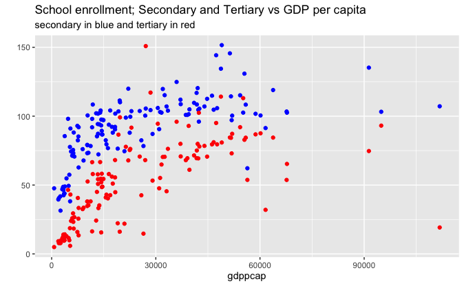

```r
df_sec_ter_gdp |> filter(year == 2020) |> drop_na(sec, ter, gdppcap) |>
  ggplot() + geom_point(aes(gdppcap, sec), col = "blue") +
  geom_point(aes(gdppcap, ter), col = "red") +
  labs(title = "School enrollment; Secondary and Tertiary vs GDP per capita",
       subtitle = "secondary in blue and tertiary in red", y = "")
```

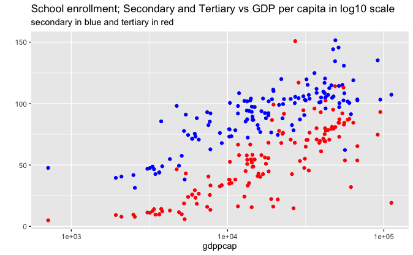

```r
df_sec_ter_gdp |> filter(year == 2020) |> drop_na(sec, ter, gdppcap) |>
  ggplot() + geom_point(aes(gdppcap, sec), col = "blue") +
  geom_point(aes(gdppcap, ter), col = "red") +
  scale_x_log10() +
  labs(title = "School enrollment; Secondary and Tertiary vs GDP per capita in log10 scale",
       subtitle = "secondary in blue and tertiary in red", y = "")
```

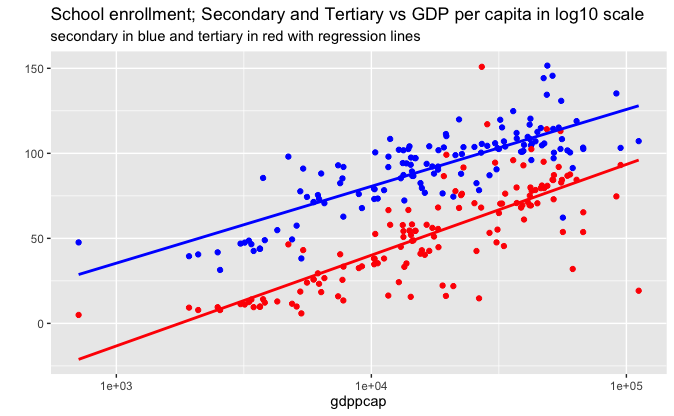

```r
df_sec_ter_gdp |> filter(year == 2020) |> drop_na(sec, ter, gdppcap) |>
  ggplot() + geom_point(aes(gdppcap, sec), col = "blue") +
  geom_point(aes(gdppcap, ter), col = "red") +
  geom_smooth(aes(gdppcap, sec), col = "blue", method = "lm", formula = 'y~x', se = FALSE) +
  geom_smooth(aes(gdppcap, ter), col = "red", method = "lm", formula = 'y~x', se = FALSE) +
  scale_x_log10() +
  labs(title = "School enrollment; Secondary and Tertiary vs GDP per capita in log10 scale",
       subtitle = "secondary in blue and tertiary in red with regression lines", y = "")
```

```r
df_sec_ter_gdp |> filter(year == 2020) |> drop_na(gdppcap, sec) |>
  lm(sec~log10(gdppcap), data = _) |> summary()
```

```
Call:
lm(formula = sec ~ log10(gdppcap), data = drop_na(filter(df_sec_ter_gdp,
    year == 2020), gdppcap, sec))

Residuals:
    Min      1Q  Median      3Q     Max
-53.777 -10.846  -1.173   9.006  66.996

Coefficients:
               Estimate Std. Error t value Pr(>|t|)
(Intercept)    -102.994     11.933  -8.631 6.38e-15 ***
log10(gdppcap)   46.088      2.841  16.222  < 2e-16 ***
---
Signif. codes:  0 ‘***’ 0.001 ‘**’ 0.01 ‘*’ 0.05 ‘.’ 0.1 ‘ ’ 1

Residual standard error: 15.64 on 157 degrees of freedom
Multiple R-squared:  0.6263,    Adjusted R-squared:  0.624
F-statistic: 263.2 on 1 and 157 DF,  p-value: < 2.2e-16
```

```r
df_sec_ter_gdp |> filter(year == 2020) |> drop_na(gdppcap, ter) |>
  lm(ter~log10(gdppcap), data = _) |> summary()
```

```
Call:
lm(formula = ter ~ log10(gdppcap), data = drop_na(filter(df_sec_ter_gdp,
    year == 2020), gdppcap, ter))

Residuals:
    Min      1Q  Median      3Q     Max
-72.696  -8.388  -0.808   8.589  89.657

Coefficients:
               Estimate Std. Error t value Pr(>|t|)
(Intercept)    -159.817     13.877  -11.52   <2e-16 ***
log10(gdppcap)   49.861      3.303   15.09   <2e-16 ***
---
Signif. codes:  0 ‘***’ 0.001 ‘**’ 0.01 ‘*’ 0.05 ‘.’ 0.1 ‘ ’ 1

Residual standard error: 19.18 on 157 degrees of freedom
Multiple R-squared:  0.592, Adjusted R-squared:  0.5894
F-statistic: 227.8 on 1 and 157 DF,  p-value: < 2.2e-16
```

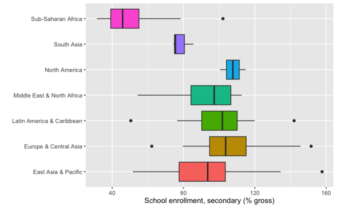

```r
df_sec_ter_gdp |> filter(year == 2020, region != "Aggregates") |> drop_na(sec, region) |>
  ggplot(aes(sec, region, fill = region)) + geom_boxplot() +
  labs(x = "School enrollment, secondary (% gross)", y = "") + theme(legend.position = "none")
```

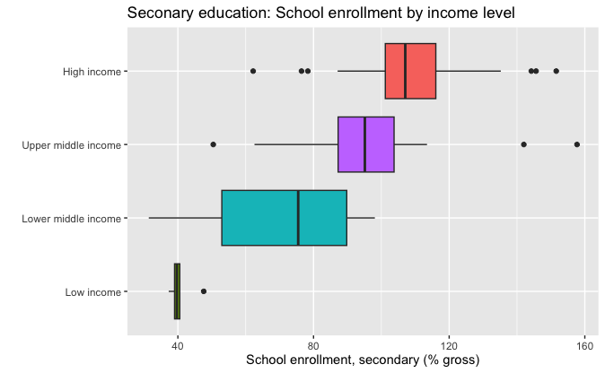

```r
df_sec_ter_gdp |> filter(year == 2020, income !="Aggregates") |> drop_na(sec, income) |>
  ggplot(aes(sec, factor(income, levels = INCOME), fill = income)) + geom_boxplot() +
  labs(title = "Seconary education: School enrollment by income level", x = "School enrollment, secondary (% gross)", y = "") + theme(legend.position = "none")
```

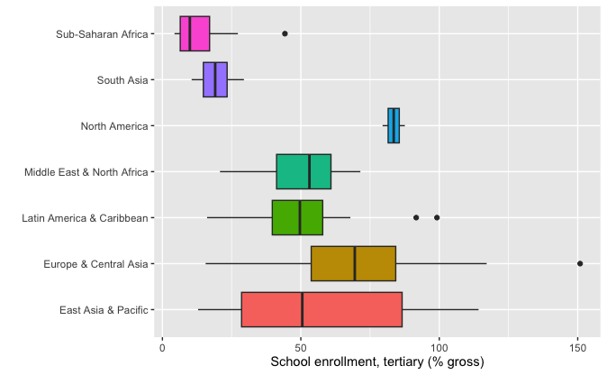

```r
df_sec_ter_gdp |> filter(year == 2020, region != "Aggregates") |> drop_na(ter, region) |>
  ggplot(aes(ter, region, fill = region)) + geom_boxplot() +
  labs(x = "School enrollment, tertiary (% gross)", y = "") + theme(legend.position = "none")
```

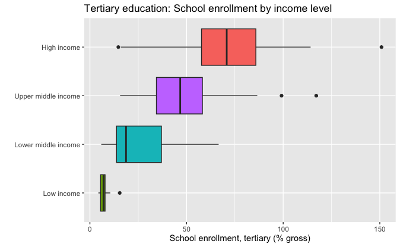

```r
df_sec_ter_gdp |> filter(year == 2020, income != "Aggregates") |> drop_na(ter, income) |>
  ggplot(aes(ter, factor(income, levels = INCOME), fill = income)) + geom_boxplot() +
  labs(title = "Tertiary education: School enrollment by income level", x = "School enrollment, tertiary (% gross)", y = "") + theme(legend.position = "none")
```

**Observations**

- Income level has more effect on school enrollment to tertiary education